# online retail

```python
import pandas as pd
df=pd.read_excel(r"c:\users\user\Documents\Online Retail\Online Retail.xlsx")
df.head()
```

|  | InvoiceNo | StockCode | Description | Quantity | InvoiceDate | UnitPrice | CustomerID | Country |
| --- | --- | --- | --- | --- | --- | --- | --- | --- |
| 0 | 536365 | 85123A | WHITE HANGING HEART T-LIGHT HOLDER | 6 | 2010-12-01 08:26:00 | 2.55 | 17850.0 | United Kingdom |
| 1 | 536365 | 71053 | WHITE METAL LANTERN | 6 | 2010-12-01 08:26:00 | 3.39 | 17850.0 | United Kingdom |
| 2 | 536365 | 84406B | CREAM CUPID HEARTS COAT HANGER | 8 | 2010-12-01 08:26:00 | 2.75 | 17850.0 | United Kingdom |
| 3 | 536365 | 84029G | KNITTED UNION FLAG HOT WATER BOTTLE | 6 | 2010-12-01 08:26:00 | 3.39 | 17850.0 | United Kingdom |
| 4 | 536365 | 84029E | RED WOOLLY HOTTIE WHITE HEART. | 6 | 2010-12-01 08:26:00 | 3.39 | 17850.0 | United Kingdom |

```python
df.tail()
```

|  | InvoiceNo | StockCode | Description | Quantity | InvoiceDate | UnitPrice | CustomerID | Country |
| --- | --- | --- | --- | --- | --- | --- | --- | --- |
| 541904 | 581587 | 22613 | PACK OF 20 SPACEBOY NAPKINS | 12 | 2011-12-09 12:50:00 | 0.85 | 12680.0 | France |
| 541905 | 581587 | 22899 | CHILDREN'S APRON DOLLY GIRL | 6 | 2011-12-09 12:50:00 | 2.10 | 12680.0 | France |
| 541906 | 581587 | 23254 | CHILDRENS CUTLERY DOLLY GIRL | 4 | 2011-12-09 12:50:00 | 4.15 | 12680.0 | France |
| 541907 | 581587 | 23255 | CHILDRENS CUTLERY CIRCUS PARADE | 4 | 2011-12-09 12:50:00 | 4.15 | 12680.0 | France |
| 541908 | 581587 | 22138 | BAKING SET 9 PIECE RETROSPOT | 3 | 2011-12-09 12:50:00 | 4.95 | 12680.0 | France |

```python
df.shape
```

```
(541909, 8)
```

```python
df.info()
```

```
<class 'pandas.core.frame.DataFrame'>
RangeIndex: 541909 entries, 0 to 541908
Data columns (total 8 columns):
 #   Column       Non-Null Count   Dtype
---  ------       --------------   -----
 0   InvoiceNo    541909 non-null  object
 1   StockCode    541909 non-null  object
 2   Description  540455 non-null  object
 3   Quantity     541909 non-null  int64
 4   InvoiceDate  541909 non-null  datetime64[ns]
 5   UnitPrice    541909 non-null  float64
 6   CustomerID   406829 non-null  float64
 7   Country      541909 non-null  object
dtypes: datetime64[ns](1), float64(2), int64(1), object(4)
memory usage: 33.1+ MB
```

```python
df.isnull().sum()
```

```
InvoiceNo           0
StockCode           0
Description      1454
Quantity            0
InvoiceDate         0
UnitPrice           0
CustomerID     135080
Country             0
dtype: int64
```

```python
df.duplicated().sum
```

```
<bound method Series.sum of 0         False
1         False
2         False
3         False
4         False
          ...
541904    False
541905    False
541906    False
541907    False
541908    False
Length: 541909, dtype: bool>
```

```python
df.describe()
```

|  | Quantity | InvoiceDate | UnitPrice | CustomerID |
| --- | --- | --- | --- | --- |
| count | 541909.000000 | 541909 | 541909.000000 | 406829.000000 |
| mean | 9.552250 | 2011-07-04 13:34:57.156386048 | 4.611114 | 15287.690570 |
| min | -80995.000000 | 2010-12-01 08:26:00 | -11062.060000 | 12346.000000 |
| 25% | 1.000000 | 2011-03-28 11:34:00 | 1.250000 | 13953.000000 |
| 50% | 3.000000 | 2011-07-19 17:17:00 | 2.080000 | 15152.000000 |
| 75% | 10.000000 | 2011-10-19 11:27:00 | 4.130000 | 16791.000000 |
| max | 80995.000000 | 2011-12-09 12:50:00 | 38970.000000 | 18287.000000 |
| std | 218.081158 | NaN | 96.759853 | 1713.600303 |

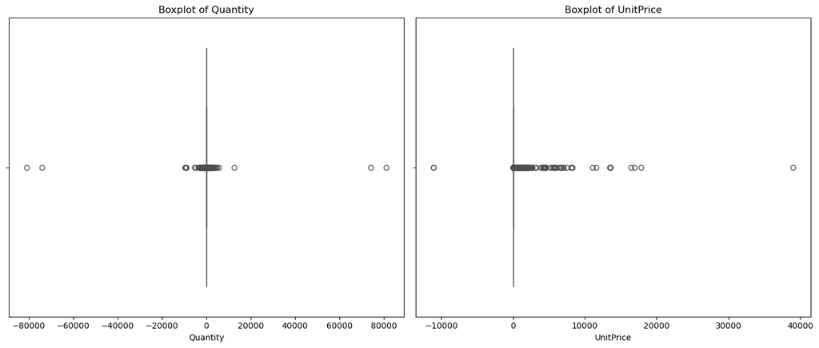

```python
import matplotlib.pyplot as plt
import seaborn as sns

fig = plt.figure(figsize=(14,6))

ax1 = fig.add_subplot(1, 2, 1)
sns.boxplot(x="Quantity", data=df, color="#FF0000", ax=ax1)
ax1.set_title("Boxplot of Quantity")

ax2 = fig.add_subplot(1, 2, 2)
sns.boxplot(x="UnitPrice", data=df, color="#0000FF", ax=ax2)
ax2.set_title("Boxplot of UnitPrice")

plt.tight_layout()
plt.show()
```

```python
df_clean = df[(df['Quantity'] > 0) & (df['Quantity'] < 1000)]
df_clean = df_clean[(df_clean['UnitPrice'] > 0) & (df_clean['UnitPrice'] < 200)]
```

Insight — Data Cleaning

در مرحلهٔ پاک‌سازی داده‌ها، مقادیر غیرمنطقی و مقادیر خارج از محدودهٔ تعریف‌شده در ستون‌های Quantity و UnitPrice حذف شدند. برای این منظور، فیلترهای منطقی بر روی این ستون‌ها اعمال شد تا تعدادهای منفی یا بسیار بزرگ و همچنین قیمت‌های غیرواقعی از مجموعه‌داده حذف شوند. در نتیجه، دیتاست df_clean از داده‌های نامعتبر پاک‌سازی شد و برای انجام تحلیل اکتشافی داده‌ها (EDA)، بررسی روند فروش و تحلیل رفتار مشتری، مناسب‌تر و قابل اتکاتر شد.

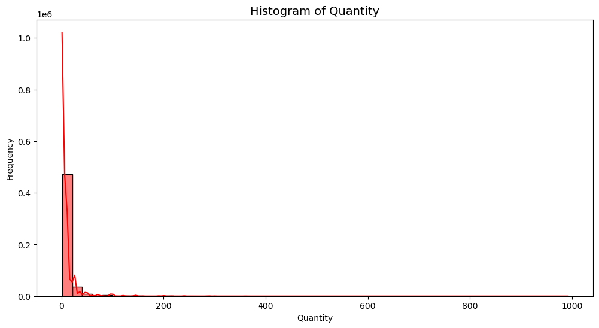

```python
import matplotlib.pyplot as plt
import seaborn as sns

plt.figure(figsize=(12,6))
sns.histplot(df_clean['Quantity'], bins=50, kde=True, color="#FF0000")
plt.title("Histogram of Quantity", fontsize=14)
plt.xlabel("Quantity")
plt.ylabel("Frequency")
plt.show()
```

Insight — توزیع Quantity

توزیع تعداد خرید (Quantity) پس از حذف مقادیر غیرمنطقی و Outlierها، یک الگوی کاملاً «راست‌چوله» را نشان می‌دهد. این یعنی بخش بسیار بزرگی از سفارش‌ها شامل تعداد کم کالا هستند و مشتری‌ها معمولاً خریدهای کوچک انجام می‌دهند. بخش کوچکی از داده‌ها شامل خریدهای بزرگ‌تر است که کاملاً طبیعی بوده و نشان‌دهنده رفتار معمول در خریدهای آنلاین است؛ جایی که سفارش‌های کوچک فراوان‌تر و سفارش‌های بزرگ بسیار محدودتر هستند. این الگو برای تحلیل رفتار مشتری، پیش‌بینی تقاضا و طراحی استراتژی‌های فروش اهمیت زیادی دارد.

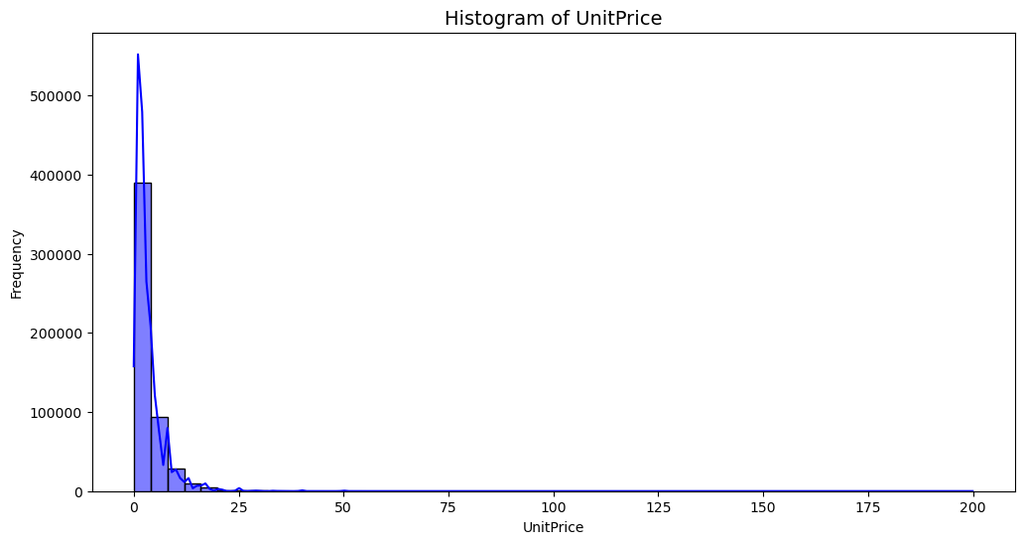

```python
plt.figure(figsize=(12,6))
sns.histplot(df_clean['UnitPrice'], bins=50, kde=True, color="#0000FF")
plt.title("Histogram of UnitPrice", fontsize=14)
plt.xlabel("UnitPrice")
plt.ylabel("Frequency")
plt.show()
```

Insight — Distribution of UnitPrice

توزیع قیمت واحد کالا (UnitPrice) پس از حذف مقادیر غیرمنطقی و Outlierها، دارای چولگی مثبت (Right-Skewed) است. این الگو نشان می‌دهد که بخش عمده‌ای از اقلام دارای قیمت‌های پایین هستند، در حالی که تنها تعداد محدودی از کالاها با قیمت‌های بالاتر عرضه می‌شوند. چنین توزیعی در بسیاری از فروشگاه‌های آنلاین رایج است و بیانگر تنوع قیمتی محصولات با تمرکز بیشتر بر کالاهای کم‌قیمت است. بررسی این الگو می‌تواند در تحلیل سودآوری، تدوین استراتژی‌های قیمت‌گذاری، شناسایی گروه‌های مختلف محصولات و درک بهتر رفتار خرید مشتریان نقش مهمی ایفا کند.

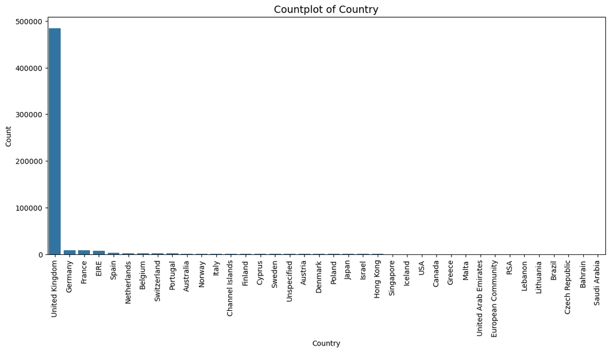

```python
plt.figure(figsize=(14,6))
sns.countplot(data=df_clean, x='Country', order=df_clean['Country'].value_counts().index)
plt.xticks(rotation=90)
plt.title("Countplot of Country", fontsize=14)
plt.xlabel("Country")
plt.ylabel("Count")
plt.show()
```

### Insight — توزیع Country

توزیع کشورها در دیتاست نشان می‌دهد که بخش بسیار بزرگی از تراکنش‌ها مربوط به کشور United Kingdom است و سایر کشورها سهم بسیار کوچکی دارند. این الگو طبیعی است زیرا فروشگاه مورد بررسی یک فروشگاه انگلیسی است و بخش عمده مشتریان آن در UK قرار دارند. این موضوع در تحلیل رفتار مشتری، بررسی بازار هدف و طراحی استراتژی‌های فروش اهمیت زیادی دارد.

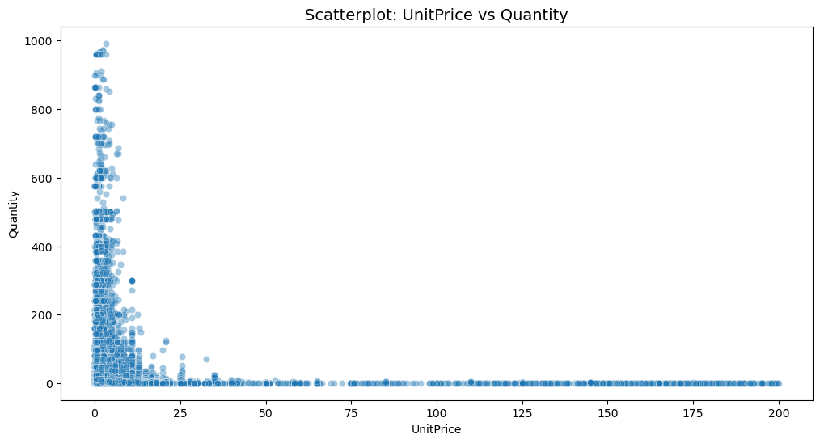

```python
plt.figure(figsize=(12,6))
sns.scatterplot(data=df_clean, x='UnitPrice', y='Quantity', alpha=0.4)
plt.title("Scatterplot: UnitPrice vs Quantity", fontsize=14)
plt.xlabel("UnitPrice")
plt.ylabel("Quantity")
plt.show()
```

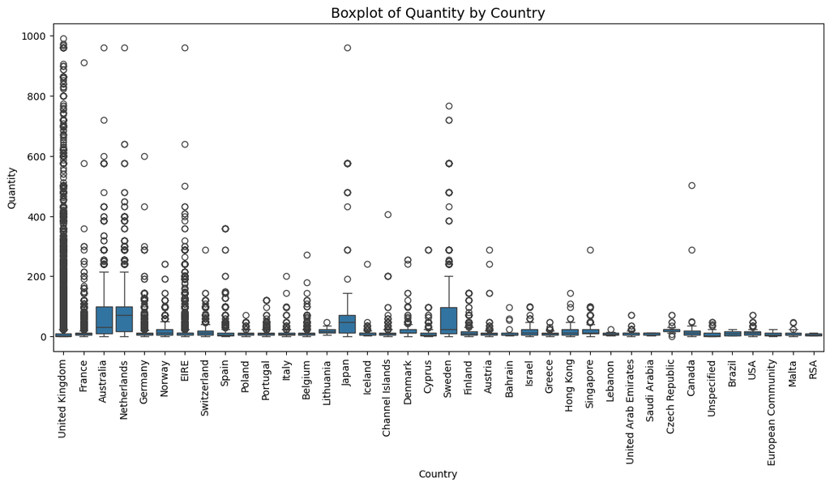

```python
plt.figure(figsize=(14,6))
sns.boxplot(data=df_clean, x='Country', y='Quantity')
plt.xticks(rotation=90)
plt.title("Boxplot of Quantity by Country", fontsize=14)
plt.xlabel("Country")
plt.ylabel("Quantity")
plt.show()
```

### Insight — Quantity by Country

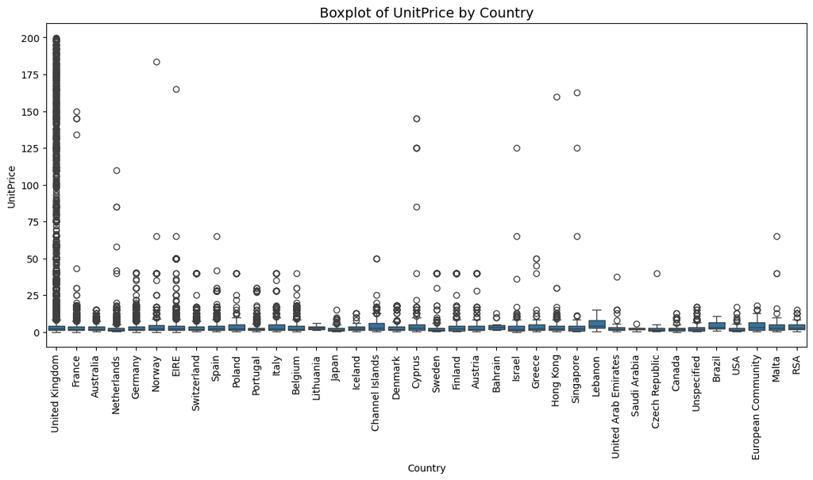

```python
plt.figure(figsize=(14,6))
sns.boxplot(data=df_clean, x='Country', y='UnitPrice')
plt.xticks(rotation=90)
plt.title("Boxplot of UnitPrice by Country", fontsize=14)
plt.xlabel("Country")
plt.ylabel("UnitPrice")
plt.show()
```

### Insight — UnitPrice by Country

نمودار Boxplot توزیع قیمت واحد کالا (UnitPrice) را در کشورهای مختلف مقایسه می‌کند. در کشور United Kingdom دامنه و پراکندگی قیمت‌ها به‌طور قابل توجهی بیشتر از سایر کشورهاست و تنوع بیشتری در قیمت کالاهای خریداری‌شده مشاهده می‌شود. این رفتار با توجه به تعداد بالای تراکنش‌ها و گستردگی محصولات موجود در UK طبیعی است. در مقابل، بسیاری از کشورها دامنهٔ محدودتری از قیمت‌ها دارند که نشان‌دهندهٔ تنوع کمتر محصولات یا حجم خرید پایین‌تر در آن‌هاست. این تفاوت در توزیع قیمت میان کشورها می‌تواند برای تحلیل الگوهای خرید، بررسی تفاوت‌های قیمتی در بازارهای مختلف و طراحی استراتژی‌های قیمت‌گذاری مورد استفاده قرار گیرد.

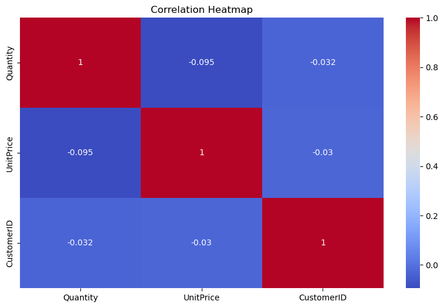

```python
plt.figure(figsize=(10,6))
sns.heatmap(df_clean.corr(numeric_only=True), annot=True, cmap='coolwarm')
plt.title("Correlation Heatmap")
plt.show()
```

### Insight — Correlation Heatmap

ماتریس همبستگی نشان می‌دهد که میان متغیرهای عددی دیتاست Online Retail هیچ رابطهٔ خطی قوی و معناداری وجود ندارد. همبستگی پایین میان Quantity و UnitPrice بیانگر آن است که قیمت واحد کالا تأثیر مستقیمی بر تعداد خرید ندارد و رفتار مشتریان تحت تأثیر عوامل دیگری شکل می‌گیرد. همچنین CustomerID نیز همبستگی قابل توجهی با سایر متغیرها ندارد که با توجه به ماهیت آن به‌عنوان یک شناسهٔ مشتری کاملاً طبیعی است. این نتایج نشان می‌دهد که برای تحلیل دقیق‌تر الگوهای فروش و رفتار مشتری، بررسی متغیرهای تکمیلی مانند نوع محصول، زمان خرید و ویژگی‌های تراکنش ضروری است.

### تحلیل نهایی EDA — Online Retail Dataset

تحلیل اکتشافی داده‌ها (EDA) در دیتاست Online Retail نشان داد که توزیع متغیرهای Quantity و UnitPrice دارای چولگی مثبت است و بخش عمده‌ای از مقادیر در محدوده‌های پایین قرار دارند. مقادیر غیرمنطقی و خارج از محدوده در این دو متغیر شناسایی و حذف شدند تا کیفیت داده‌ها برای تحلیل‌های بعدی افزایش یابد.

بررسی رابطهٔ Quantity و UnitPrice با استفاده از Scatter Plot نشان داد که میان این دو متغیر الگوی خطی مشخصی وجود ندارد. این موضوع بیانگر آن است که قیمت واحد کالا تأثیر مستقیمی بر تعداد خرید ندارد و رفتار خرید مشتریان تحت تأثیر عوامل دیگری مانند نوع محصول، زمان خرید و ویژگی‌های مشتری شکل می‌گیرد.

مقایسهٔ توزیع Quantity در کشورهای مختلف با استفاده از Boxplot نشان داد که کشور United Kingdom دامنهٔ گسترده‌تری از مقادیر خرید را نسبت به سایر کشورها دارد که با تعداد بالای تراکنش‌های این کشور سازگار است. همچنین توزیع UnitPrice در UK تنوع بیشتری از قیمت‌ها را نشان می‌دهد، در حالی که بسیاری از کشورها دامنهٔ محدودتری دارند. این تفاوت‌ها می‌تواند برای تحلیل الگوهای خرید و بررسی ویژگی‌های بازارهای مختلف مورد استفاده قرار گیرد.

تحلیل Correlation Heatmap نیز نشان داد که میان متغیرهای عددی دیتاست رابطهٔ خطی قوی و قابل توجهی وجود ندارد. همبستگی پایین میان Quantity و UnitPrice نشان می‌دهد که قیمت واحد کالا عامل تعیین‌کننده‌ای در میزان خرید نیست. همچنین CustomerID نیز همبستگی معناداری با سایر متغیرها ندارد که با توجه به ماهیت آن طبیعی است.

در مجموع، نتایج EDA نشان می‌دهد که بررسی توزیع متغیرها، روابط میان ویژگی‌های عددی و تفاوت‌های جغرافیایی دید اولیهٔ مناسبی از ساختار داده و الگوهای خرید ارائه می‌دهد. با این حال، برای دستیابی به درک عمیق‌تر از رفتار مشتری و عملکرد فروش، تحلیل متغیرهای تکمیلی مانند Product Description، زمان خرید، تعداد تراکنش‌های مشتریان، مبلغ فروش و الگوهای خرید در طول زمان ضروری است. این یافته‌ها می‌توانند مبنایی برای تحلیل‌های پیشرفته‌تر، بخش‌بندی مشتریان، بررسی روند فروش و تصمیم‌گیری‌های تجاری باشند.